# Process data for DESeq analysis of U2AF1, U2AF2, SF1

Author

Kim Nguyen

Published

July 10, 2025

# 1 Introduction

## 1.1 Background information

This practical course (F2/ 3-month internship) is aimed to investigate the role of trans-acting RNA splicing factors in the regulation of alternative splicing, and how their dysfunction can contribute to cancer and tumor growth. The project begins by exploring the fundamental mechanisms of splicing, particularly the involvement of key trans-factors such as U2AF2, U2AF1, and SF1. These proteins play crucial roles in recognizing the 3′ splice site (AG), facilitating exon definition, and promoting lariat formation during intron removal, ultimately contributing to the production of mature mRNA.

## 1.2 Objectives / Research Questions

Learning objectives: - Idenitfy key significantly regulated genes and their expression patterns. - Analyze relationships between DEG statistics. - Understand functional gene associations using Gene Ontology terms (enrichGO and g:GOST) - Explore functional correlation among splice factors * Hypotheses: - Gene expression and Splicing interaction networks are changed upon knockdown of U2AF2, U2AF1, and SF1 leading to changes in their functional enrichment.

## 1.3 Significance of the Study

Alternative splicing plays a critical role in gene regulation and has been widely implicated in cancer development. This analysis is further researching how the splicing factors, particularly 3 genes of interest (U2AF1, U2AF2, and SF1), influences revealing insight into oncogenic process and potential therapeutic targets.

## 1.4 Data Sources

For this study, publicly raw RNA-seq datasets (fastq files) were obtained from the ENCODE project, which are silienced or reduced the expression using short hairpin RNA (shRNA) targeting U2AF2, U2AF1, and SF1 in the HepG2 liver cancer cell line (originating from a 15-year-old white male donor). Both shRNA-treated and control samples are replicated isogenic (that are genetically identical) which help reduce variability and makes it easier to attribute observed differences.

The data analysis pipeline includes several key steps: ## Data Preprocessing and tools (version number) - quality control using FastQC and MultiQC - adapter trimming with Trimmomatic - read alignment to the reference genome using STAR aligner - quantification of gene expression with HTSeq-count - visualization of mapped reads using IGV genome browser.

## 1.5 Exploratory Data Analysis (EDA)

- PCA and clustering: is a dimensionality reduction method that is used to identify the directions (principal components) to capture the variance between different datasets. PC1 and PC2 respectively represent the 1st and 2nd greatest variation in datasets and are plotted to visualize sample clustering. In an ideal experiment, all replicates from same sample are expected to cluster together and the KD groups should cluster apart away from control one.
- Read count

# 2 Input

- Library

```r
# For Plotting & Visualization
library(ggplot2)
library(tidyverse)
library(plotly)
library(RColorBrewer)
library(ggrepel)
library(markdown)
library(ggrastr)
library(ggpointdensity)
library(magrittr)
library(dplyr)
library(gridExtra)
library(magrittr)
library(magick)
library(RColorBrewer)
library(colorRamp2)
library(ggvenn)
library(kableExtra)
library(ggstatsplot)
library(ggdist)
library(ggsci)
library(ggsignif) # for geom_signif()
library(ggrain)

# For analysis
library(pheatmap)
library(ComplexHeatmap)
library(pcaExplorer) #interactive tool for exploring PCA
library(DESeq2)
library(gprofiler2)
library(clusterProfiler)
library(enrichplot)
library(showtext)# Effect size for U2AF2 pair

# annotated human genome
library(org.Hs.eg.db)
library(AnnotationDbi)
library(Homo.sapiens)

#to combine multiple ggplot
library(patchwork)
library(reshape2)
library(ggpubr)

#outpath for all results of DESeq2 analysis
outpath = "/Users/tinkienoob/Master_thesis/HepG2_DESeq_analysis"
```

```r
dds = DESeqDataSetFromHTSeqCount(sampleTable = sampleTable,
                                 directory = countFolder,
                                 design = ~ condition)
```

- Running DESeq2 analysis to identify differentially expressed genes

```r
# Deseq data object
dds = DESeq(dds)
# Save dds outout in the outpath as rds file
saveRDS(dds, file = paste0(outpath, "dds_DESeq2.dds"))
```

## 2.1 Check sizeFactor normalizing read counts

One of the first step in the DE analysis workflow is count normalization, which is necessary to make accurate comparisons of gene expression between samples. Normalization is the process to scale raw count values to account for the “uninteresting” factors (usually sequencing depth, gene length, or RNA composition) across samples. There are several common normalization methods: CPM (counts/ million), TPM (transcripts/ kilobase milion), RPKM/ FPKM (reads-fragments/ kilobase of exon/ milion reads-fragments mapped), DESeq2’s median of ratios. (Source: https://hbctraining.github.io/DGE_workshop/lessons/02_DGE_count_normalization.html) What is sizeFactor? It represents scaling factors for each sample to normalized raw counts and can be adjusted for easily comparision

## 2.2 Annotate all genes with R human genome package

There are probably many geneIds having the same gene name or it also could be same geneIds but different versions having the same gene name which create multiple similar geneIds in the gene annotation package. The version of the genes is used to track changes over time due to updates, transcript or feature changes, etc.

```r
# calculate dds result (however, it calculate only 1 pair between U2AF2 and its control)
res = results(dds, alpha = 0.05)

# Convert dds result into dataframe
res.df = as.data.frame(res)

# Remove version of gene to match with geneIDs symbol in the package
geneIDs = sub("\\..*", "", rownames(res.df))  # dds from DESeq2 object

# Annotate geneID with geneNames using R human genome package
gene_anno = AnnotationDbi::select(org.Hs.eg.db,
                                  keys = geneIDs,
                                  columns = "SYMBOL",
                                  keytype = "ENSEMBL") #ENS suffix is derived from Ensembl

# 1 gene name perhaps has different geneID/ same geneID but different versions
# GeneIDs and gene names are only needed, therefore, no needs to worry about the changes of different versions.
gene_anno = gene_anno[!duplicated(gene_anno$ENSEMBL), ]

save(gene_anno,
     file = "/Users/tinkienoob/Master_thesis/HepG2_DESeq_analysis/gene_anno.RData")
```

- Multiple testing correction: To reduce false positives when testing thousands of genes simultaneously. In this analysis, Benjamini-Hochberg (false discovery rate) is applied to control for multiple hypothesis testing.

# 3 DESeq result of each pair (control and KO)

```r
# Create a function to apply for each DESeq2 result
res_function = function(deseq_result){
  # 1st, convert dds result into df
  deseq_result.df = as.data.frame(deseq_result)
  # shrink raw values from dds result by ashr type
  deseq_result.ashr = lfcShrink(dds = dds,
                                contrast = contrast,
                                res = deseq_result,
                                type = "ashr")
  # Add GeneID column
  deseq_result.df$GeneID = geneIDs
  # convert dds.shrinkage.ashr result into df then also add geneID column
  deseq_result.ashr = as.data.frame(deseq_result.ashr)
  deseq_result.ashr$GeneID = geneIDs
  deseq_result.ashr = dplyr::select(deseq_result.ashr, c("GeneID", "log2FoldChange"))

  # dds.shrinkage.ashr result then is merged with dds result df using geneID and is added suffix at the end of colnames to differentiate
  deseq_result.df = inner_join(deseq_result.df, deseq_result.ashr, by = "GeneID", suffix = c("", ".ashr"))

  # assign gene name for geneID using gene_anno
  deseq_result.df2 = inner_join(deseq_result.df, gene_anno, by = c("GeneID" = "ENSEMBL"))

  # Add regulated column
  # If padj < 0.05, set TRUE (regulated), otherwise, FALSE
  deseq_result.df2$regulated = deseq_result.df2$padj < 0.05
  deseq_result.df2$regulated[is.na(deseq_result.df2$regulated)] = FALSE #If NA, set FALSE

  deseq_result.df2 = dplyr::mutate(deseq_result.df2, up_down = case_when(
    regulated & log2FoldChange > 0 ~ "up",
    regulated & log2FoldChange < 0 ~ "down",
    TRUE ~ "not regulated" #if none of 2 above are the cases, then "not regulated"
  ))

  # Specify my GOI
  deseq_result.df2 = dplyr::mutate(deseq_result.df2, myLabel = case_when(
    SYMBOL == "U2AF2" ~ SYMBOL,
    SYMBOL == "U2AF1" ~ SYMBOL,
    SYMBOL == "SF1" ~ SYMBOL,
    TRUE ~ NA_character_))

return(deseq_result.df2)
}
```

# 4 EXPLONATORY DATA ANALYSIS

## 4.1 P value and P-adj distribution

**U2AF1**

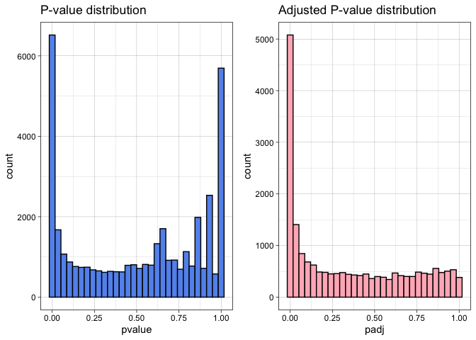

```r
hist_U2AF1 = histogram_plot(deseq_result.df = res_U2AF1.df)
grid.arrange(hist_U2AF1$p.hist, hist_U2AF1$padj.hist, ncol =2)
```

**U2AF2**

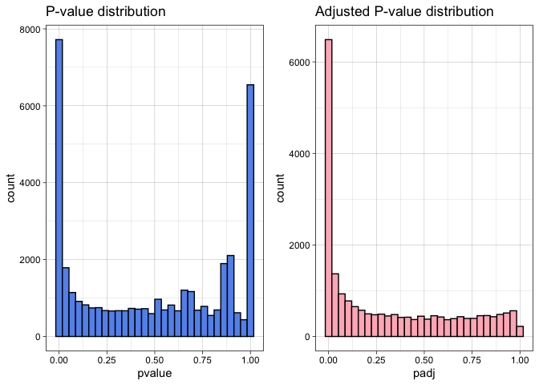

```r
hist_U2AF2 = histogram_plot(deseq_result.df = res_U2AF2.df)
grid.arrange(hist_U2AF2$p.hist, hist_U2AF2$padj.hist, ncol =2)
```

**SF1**

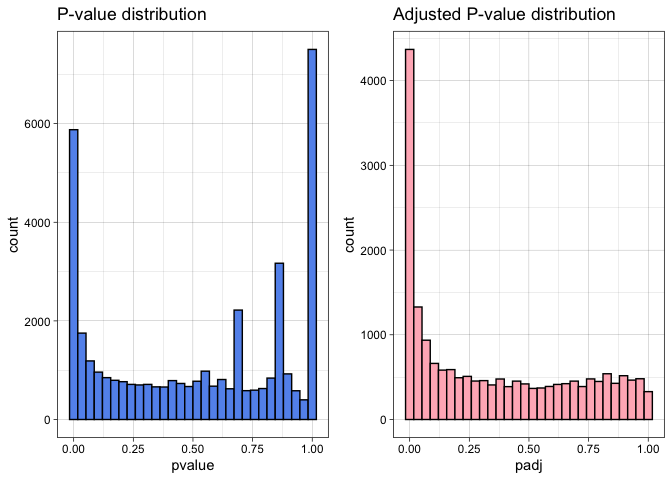

```r
hist_SF1 = histogram_plot(res_SF1.df)
grid.arrange(hist_SF1$p.hist, hist_SF1$padj.hist, ncol = 2)
```

## 4.2 Hierarchical Clustering Heatmap/ Sample distance heatmap

This heatmap shows how different between all samples for evaluating strong patterns between conditions and potential outliers based on normalized gene expression values which is complementary to PCA. Clustered samples, hence, are expected to be similar to PCA plot observation.

- Log-transformed data to stabilize variance and blind = F to not ignore differences in conditions and biological variation.

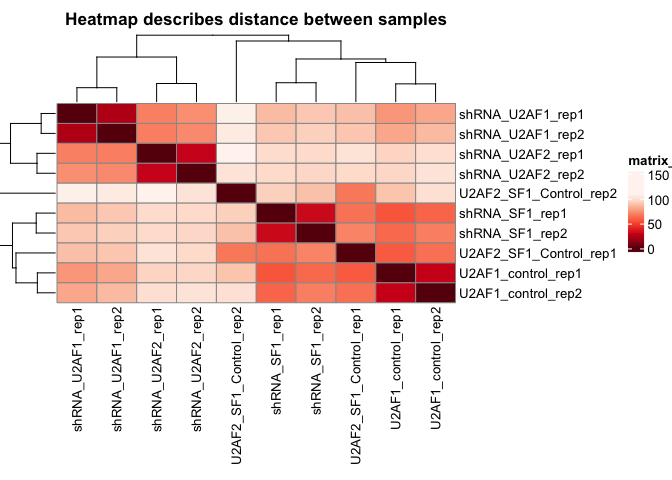

```r
# Perform rlog transformation
rld = rlog(dds, blind = F)

# Compute pairwise distances between samples
sampleDist = dist(t(assay(rld)))
sampleMatrix = as.matrix(sampleDist)

# Make a color gradient palette for heatmap
color = colorRampPalette(rev(brewer.pal(9, "Reds")))(255)

# Create heatmap using pheatmap (simple)
pheatmap(sampleMatrix,
         col = color,
         clustering_distance_rows = sampleDist,
         clustering_distance_cols = sampleDist,
         cellwidth = 30,
         cellheight = 15,
         main = "Heatmap describes distance between samples")
```

# 5 Principle component analysis

Principal Component Analysis (PCA) helps assess global gene expression patterns across samples. PCA plot is useful for visualizing relationships between samples based on their gene expression profiles which then can be evaluated whether the effect of experimental covariates or detection of batch effects. What is a batch effect? The batch effect is usually caused by an unbalanced experimental design, which has the same procedure but different facilities/ reagents, equipment, etc. (non-biological reasons). Samples with replicates that are similar in their gene expression will cluster close together; meanwhile, the more different the expression, the more separated the samples. PC1 (first principal component) is mostly aligned with the experimental covariate of interest or captures the most largest variance in data (between control and KD samples). Followed by PC2, the second component, is aligned with the sequencing protocol (between replicates) that captures technical variation helping identify batch effects.

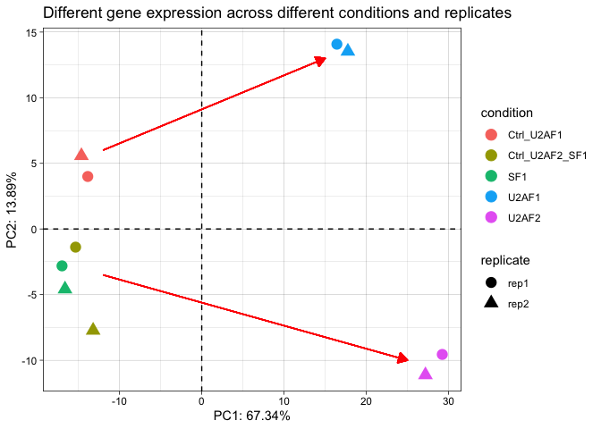

```r
# Create PCA data from plotPCA but with returnData = T
PCAdata= plotPCA(rld, intgroup = c("condition", "replicate"), returnData = T)

# Round PCA data to make percent Variance
percentVariance = round(attr(PCAdata, "percentVar")*100, digits = 2)

# Create PCA plot
ggplot(PCAdata, aes(PC1, PC2, color = condition, shape = replicate)) +
  geom_point(size = 4) +
  labs(x= paste0("PC1: ", percentVariance[1], "%"),
       y= paste0("PC2: ", percentVariance[2], "%")) +
  theme_linedraw() +
  ggtitle("Different gene expression across different conditions and replicates") +
  geom_hline(yintercept = 0, linetype = "dashed") +
  geom_vline(xintercept = 0, linetype = "dashed") +
  geom_segment(aes(x =-12, y = -3.5, xend = 25, yend = -10),
    arrow = arrow(length = unit(0.3, "cm"), type = "closed"),
    color = "red") +
  geom_segment(aes(x =-12, y = 6, xend = 15, yend = 13),
    arrow = arrow(length = unit(0.3, "cm"), type = "closed"),
    color = "red")
```

Both U2AF1 and U2AF2 KD samples are separated away from their respective control, indicating the depletion of these genes that might cause differential gene expression. In contrast, SF1 depletion condition clusters near by its control which could suggest that SF1 KD are most likely giving minimal disruption on expression. Moreover, batch effect is detected on U2AF2_SF1 control between their 2 replicates (in specific). Therefore, further quality control or assessment should be taken to later decide whether this control sample will be keep for downstream DESeq2 analysis or not.

# 6 Count plots comparing each pair of control and depletion condition

A count plot displays the frequency or how many counts of observations in each categorical variables which is usually used to compare or identify the trends/ patterns/ differences between categories. For eg, in this analysis, count plots are utilized to determine number of read counts across each pair of gene KD sample and its control (without depletion) which then represents if the gene expression (number of read counts) is about to go up or down upon specific gene KD.

```r
# choose only GOI from gene_anno df
my.genes = dplyr::mutate(gene_anno, myLabel = case_when(
  SYMBOL == "U2AF1" ~ "U2AF1",
  SYMBOL == "U2AF2" ~ "U2AF2",
  SYMBOL == "SF1" ~ "SF1",
  TRUE ~ NA
))
# remove all NA value and filter only GOI
myGenes = my.genes[!is.na(my.genes$myLabel),]

# Create a function for
normalized_counts = function(dds, pair){
  #Get all normalized counts using sizeFactors
  normalized_reads <- DESeq2::counts(dds, normalized=TRUE)

  #choose each pair of condition for comparison
  pair_count = colnames(normalized_reads)[colData(dds)$condition %in% pair]
  #pair of condition = column in df
  sub_count = normalized_reads[, pair_count]

  #Convert counts result into data frame and add GeneID column
  normalized_reads.df = as.data.frame(sub_count)

  #add geneID column into df
  normalized_reads.df$GeneID = geneIDs

  #Convert normal df into ggplot2 compatible df
  #melt() transforms the wide data frame (genes as rows, samples as columns) into a long format that ggplot2 understands.
  normalized_reads.df2 = melt(normalized_reads.df, id.vars = "GeneID", variable.name = "sample", value.name = "norm.count")
  #add condition column that matches between data
  normalized_reads.df2$condition = colData(dds)$condition[match(normalized_reads.df2$sample, colnames(dds))]
  #add replicate column also to make sure they are matched
  normalized_reads.df2$replicate = colData(dds)$replicate[match(normalized_reads.df2$sample, colnames(dds))]

  # merge df with GOI df using GeneID = ENSEMBL
  normalized_reads.df2 = left_join(normalized_reads.df2, my.genes, by = c("GeneID" = "ENSEMBL"))
  # from df above, choose only GOI to count
  normal.counts = normalized_reads.df2 %>%
    filter(normalized_reads.df2$myLabel %in% myGenes$myLabel)

return(list(normalized_reads.df2 = normalized_reads.df2, normal.counts = normal.counts))
}

# apply function to get normalized read count of each pair of condition (shRNA vs control)
# then create a count plot based on reads count of only GOI
U2AF1_counts = normalized_counts(dds, pair = c("U2AF1", "Ctrl_U2AF1"))

c1 = ggplot(U2AF1_counts$normal.counts, aes(x=condition, y=norm.count, col = myLabel)) +
  geom_point(size = 6, alpha = 0.7) +
  scale_y_log10() +
  facet_wrap(~ SYMBOL) +
  theme_light(base_size = 10) +
  ggtitle("U2AF1 dataset") +
  labs(x = NULL, y = NULL, color = "Genes of Interest") +
  scale_color_manual(values = c("U2AF1" = "#F5B355", "U2AF2" = "#C43142", "SF1" = "#4D6291"))

U2AF2_counts = normalized_counts(dds, pair = c("U2AF2", "Ctrl_U2AF2_SF1"))

c2 = ggplot(U2AF2_counts$normal.counts, aes(x=condition, y=norm.count, color = myLabel)) +
  geom_point(size = 6, alpha = 0.7) +
  scale_y_log10() +
  facet_wrap(~ SYMBOL) +
  theme_light(base_size = 10) +
  ggtitle("U2AF2 dataset") +
  labs(x = NULL, y = NULL, color = "Genes of Interest") +
  scale_color_manual(values = c("U2AF1" = "#F5B355", "U2AF2" = "#C43142", "SF1" = "#4D6291"))

SF1_counts = normalized_counts(dds, pair = c("SF1", "Ctrl_U2AF2_SF1"))

c3 = ggplot(SF1_counts$normal.counts, aes(x=condition, y=norm.count, color = myLabel)) +
  geom_point(size = 6, alpha = 0.7) +
  scale_y_log10() +
  facet_wrap(~ SYMBOL) +
  theme_light(base_size = 10) +
  ggtitle("SF1 dataset") +
  labs(x = NULL, y = NULL, color = "Genes of Interest") +
  scale_color_manual(values = c("U2AF1" = "#F5B355", "U2AF2" = "#C43142", "SF1" = "#4D6291"))

U2AF2_COUNTs = normalized_counts(dds, pair = c("U2AF2", "Ctrl_U2AF1"))

c4 = ggplot(U2AF2_COUNTs$normal.counts, aes(x=condition, y=norm.count, color = myLabel)) +
  geom_point(size = 6, alpha = 0.7) +
  scale_y_log10() +
  facet_wrap(~ SYMBOL) +
  theme_light(base_size = 10) +
  ggtitle("U2AF2 dataset") +
  labs(x = NULL, y = NULL, color = "Genes of Interest") +
  scale_color_manual(values = c("U2AF1" = "#F5B355", "U2AF2" = "#C43142", "SF1" = "#4D6291"))
```

In the comparison between U2AF2 shRNA and U2AF2_SF1 control with batch effects between 2 replicates (founded in PCA plot), it’s unreliable to tell whether U2AF2 shRNA KD is actually downregulate/ being knocked down or not for comparison. That’s why it came to the solution which U2AF1 control is used to compare. U2AF1 control is used as alternative reference. Technically, U2AF1 control has the similar shRNA KD targeting genes to U2AF2_SF1 control and processing pipeline but proceed in different time point (different day). As a result, U2AF2 KD sample shows reduced counts for U2AF2 supporting the effectiveness of shRNA knockdown. This would help interpret when U2AF2 control is unreliable.

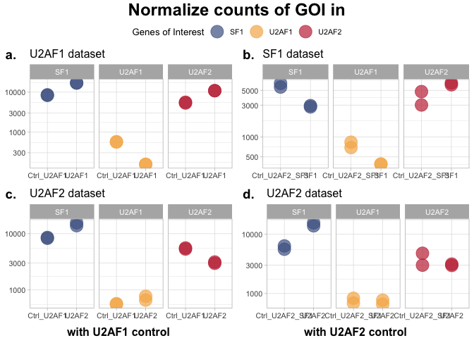

```r
# Get all count plots into 1 frame
c5 = ggarrange(c1, c3, c4, c2,
          labels = c("a.", "b.", "c.", "d."),
          nrow= 3,
          ncol = 2,
          heights = c(1,1,0.05), # give some space for column labeling
          legend = "top",
          common.legend = TRUE)

# Give general annotate for whole frame
annotate_figure(c5,
                top = text_grob("Normalize counts of GOI in", color = "black", face = "bold", size = 18),
                arrangeGrob(text_grob("with U2AF1 control", face = "bold", size = 12), # label for each column
                            text_grob("with U2AF2 control", face = "bold", size = 12),
                            ncol = 2,
                            heights = c(0.05, 1)))
```

So the question is that should U2AF1 control be used or U2AF2 control be kept for further analysis?

# 7 Splicing annotation - Core spliceosome components

Input annotation file collected from paper: https://www.science.org/doi/10.1126/science.adn8105 (Malgorzata E. Rogalska et al. ,Transcriptome-wide splicing network reveals specialized regulatory functions of the core spliceosome.Science386,551-560(2024).DOI:10.1126/science.adn8105) which contain gene names and geneID of core spliceosome components (from both major and minor spliceosomes) and associated factors, RNA binding proteins with known regulatory functions in AS, , and RNA-modifying enzymes and chromatin-related factors linked to splicing regulation.

```r
library(readxl)
anno_xlsx = "/Users/tinkienoob/Master_thesis/HepG2_DESeq_analysis/AS genes.xlsx"
as_anno = read_excel(anno_xlsx) %>%
  dplyr::select(c("Gene.Symbol", "Ensemble.Gene.ID")) %>%
  dplyr::rename(
    splice_SYMBOL = Gene.Symbol,
    splice_ENSEMBL = Ensemble.Gene.ID
  )

res_list1 = list(U2AF1 = res_U2AF1.df, U2AF2_ctrlU2AF2 = res_U2AF2.df, SF1_ctrlU2AF2 = res_SF1.df, U2AF2_ctrlU2AF1 = res_U2AF2_ctrlAF1.df, SF1_ctrlU2AF1 = res_SF1_ctrlAF1.df)
```

## 7.1 LFC scatter plot comparing between 2 datasets with different controls

To answer the above question, scatter plot of LFC between 2 set of data (shRNA U2AF2 and U2AF2 control vs. shRNA U2AF2 and U2AF1 control) are executed to evaluate the control samples and validate relation between datasets. Similar to shRNA SF1 and its controls.

Each plot compares DE results between KD samples and 2 controls (U2AF2 KD vs. U2AF2_SF1 control or vs. U2AF1 control)

As the result, if the R values of regression lines (line of best fit) between 2 variables (datasets) are high, the relationship of variables should be strong showing how one variablle tends to change as the other changes. Otherwise, weak relationship is described by the low R value. The reason causing low correlation and regression is due to outliers (genes regulate in different directions (up or down) between 2 variables. The more outliers, the lower the R values)

```r
# Create a function
log2FC_compare = function(d1, d2, var1, var2) {

  # Merge 2 datasets in to 1 df
  d1_d2_df = left_join(d1, d2, by = "GeneID", suffix = c(var1, var2))

  #add SYMBOL/ gene name column
  d1_d2_df$SYMBOL = as_anno$splice_SYMBOL[match(d1_d2_df$GeneID, as_anno$splice_ENSEMBL)]

  # Add regulated column if a gene regulated either in only 1 dataset or both
  d1_d2_df = d1_d2_df %>% mutate(
    regulate_direction = case_when(
      .[[paste0("regulated", var1)]] & .[[paste0("regulated", var2)]] == TRUE ~ "both",
      .[[paste0("regulated", var1)]] & !.[[paste0("regulated", var2)]] == TRUE ~ paste("only",var1),
      !.[[paste0("regulated", var1)]] & .[[paste0("regulated", var2)]] == TRUE ~ paste("only",var2),
      TRUE ~ NA), # If genes are nonregulated, assign it as NA
    GOI = case_when(
      grepl("U2AF2", SYMBOL) ~ SYMBOL,
      grepl("U2AF1", SYMBOL) ~ SYMBOL,
      grepl("SF1", SYMBOL) ~ SYMBOL,
      grepl("SRSF3", SYMBOL) ~ SYMBOL,
      grepl("SRSF1", SYMBOL) ~ SYMBOL,
      grepl("SRSF7", SYMBOL) ~ SYMBOL,
      grepl("SRRM2", SYMBOL) ~ SYMBOL,
      grepl("SON1", SYMBOL) ~ SYMBOL,
      grepl("RNPS1", SYMBOL) ~ SYMBOL,
      TRUE ~ NA)) # Assign all GOI related to splicing using grepl()

  # Arrange regulate = FALSE first so they will be plotted first => points will be backwards and remove NA
  d1_d2_df = d1_d2_df %>%
  arrange(!is.na(regulate_direction))

return(d1_d2_df)
}
```

At the end, there should be 4 lines with correlation values among 4 different groups (genes regulate in both dataset, or only 1 of them, or none of them - nonregulated).

**U2AF2 vs. U2AF2 and U2AF1 controls**

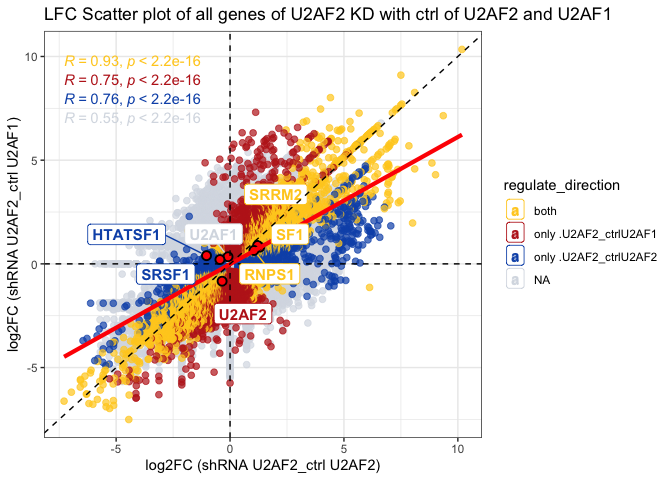

```r
# apply function on 2 datasets
U2AF2_U2AF2_ctrlU2AF1_df = log2FC_compare(res_list1$U2AF2_ctrlU2AF2, res_list1$U2AF2_ctrlU2AF1, ".U2AF2_ctrlU2AF2", ".U2AF2_ctrlU2AF1")

# LFC scatter plot
ggplot(
  U2AF2_U2AF2_ctrlU2AF1_df,
  aes(x = log2FoldChange.U2AF2_ctrlU2AF2,
      y = log2FoldChange.U2AF2_ctrlU2AF1,
      label = GOI,
      color = regulate_direction)) +
  # All genes
  geom_point(aes(color = regulate_direction), size = 2, alpha = 0.7) +
  # GOI genes in black and larger
  geom_point(data = subset(U2AF2_U2AF2_ctrlU2AF1_df, !is.na(GOI)),
             color = "black", stroke = 1, size = 2.5, shape = 21, fill = "red") +
  scale_color_manual(
    values = c("both" = "#FFCD22FF",
               "only .U2AF2_ctrlU2AF2" = "#0E54B6FF",
               "only .U2AF2_ctrlU2AF1" = "#BD241EFF"),
               na.value = "#D7DCE4FF") +
  geom_hline(yintercept = 0, linetype = "dashed") +
  geom_vline(xintercept = 0, linetype = "dashed") +
  geom_smooth(method = "lm", se = FALSE, color = "red", linewidth = 1.5, alpha = 0.8) +
  geom_label_repel(aes(label = GOI, color = regulate_direction),
    box.padding = 0.5,
    point.padding = 0.5,
    size = 4,
    label.size = 0.3,
    max.overlaps = 80,   # how all labels regardless of overlap
    force = 1.5,           # repel force; increase if still overlapping
    force_pull = 0.7,
    fontface = "bold") +
  geom_abline(linetype = "dashed") +
  stat_cor(method = "pearson") + # group all data in a single group
  labs(
    x = "log2FC (shRNA U2AF2_ctrl U2AF2)",
    y = "log2FC (shRNA U2AF2_ctrl U2AF1)",
    title = "LFC Scatter plot of all genes of U2AF2 KD with ctrl of U2AF2 and U2AF1") +
  theme_bw()
```

**SF1 vs. U2AF2 and U2AF1 controls**

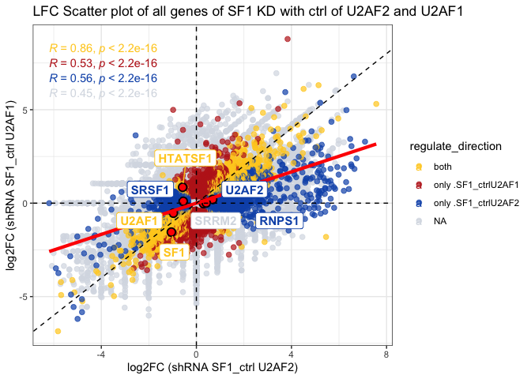

```r
SF1_SF1_ctrlU2AF1_df = log2FC_compare(res_list1$SF1_ctrlU2AF2, res_list1$SF1_ctrlU2AF1, ".SF1_ctrlU2AF2", ".SF1_ctrlU2AF1")

s4 = ggplot(
  SF1_SF1_ctrlU2AF1_df,
  aes(x = log2FoldChange.SF1_ctrlU2AF2,
      y = log2FoldChange.SF1_ctrlU2AF1,
      label = GOI,
      color = regulate_direction)) +
  # All genes
  geom_point(aes(color = regulate_direction), size = 2, alpha = 0.7) +
  # GOI genes in black and larger
  geom_point(data = subset(SF1_SF1_ctrlU2AF1_df, !is.na(GOI)),
             color = "black", stroke = 1, size = 3, shape = 21, fill = "red") +
  scale_color_manual(
    values = c("both" = "#FFCD22FF",
               "only .SF1_ctrlU2AF2" = "#0E54B6FF",
               "only .SF1_ctrlU2AF1" = "#BD241EFF"),
               na.value = "#D7DCE4FF") +
  geom_hline(yintercept = 0, linetype = "dashed") +
  geom_vline(xintercept = 0, linetype = "dashed") +
  geom_smooth(method = "lm", se = FALSE, color = "red", linewidth = 1.5, alpha = 0.8) +
  geom_label_repel(aes(label = GOI,
                       color = regulate_direction,
                       fontface = "bold"),
    box.padding = 0.5,
    point.padding = 0.5,
    size = 4,
    label.size = 0.3,
    max.overlaps = 80,   # how all labels regardless of overlap
    force = 1.5,           # repel force; increase if still overlapping
    force_pull = 0.7,
    show.legend = FALSE) +
  geom_abline(linetype = "dashed") +
  stat_cor( method = "pearson") +
  labs(
    x = "log2FC (shRNA SF1_ctrl U2AF2)",
    y = "log2FC (shRNA SF1_ctrl U2AF1)",
    title = "LFC Scatter plot of all genes of SF1 KD with ctrl of U2AF2 and U2AF1") +
  theme_bw()
s4
```

SF1 gene KD is downregulated in both datasets. Similar to U2AF2 results, regulated genes between 2 datasets has pretty high correlation.

Therefore, we could tell that overall regulated gene expression pattern is high correlation/ consistent.

Create a list of all dds result

```r
# Extract only regulated genes from each dataset and merge them but column for violin plot
regulate_df1 = purrr::map(res_list1, function(x) {
  filter(x, regulated == TRUE) %>%
    dplyr::select(c("log2FoldChange", "GeneID", "up_down", "padj"))
}) %>%
  purrr::keep(~ inherits(.x, "data.frame"))

# first merge all df by row then create short function
reg_violin = do.call(rbind, Map(function(df, name_df) {
  # add data_condition of each df = name_df
  df$data_condition = name_df
  return(df)},
  regulate_df1, names(regulate_df1)))

upreg_violin = reg_violin %>%
  filter(up_down == "up")

downreg_violin = reg_violin %>%
  filter(up_down == "down")
```

# 8 Rainplot compare 5 different datasets

**Rainplot**

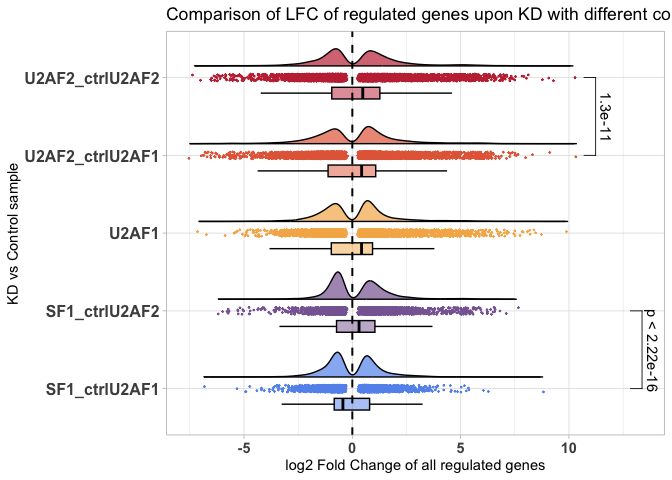

```r
# Define pairwise comparisons
pair_comparisons = list(c("U2AF2_ctrlU2AF2", "U2AF2_ctrlU2AF1"),
                        c("SF1_ctrlU2AF2","SF1_ctrlU2AF1"))

ggplot(reg_violin,
       aes(x = data_condition, y = log2FoldChange, fill = data_condition, color = data_condition)) +
  geom_rain(likert = TRUE, seed = 123, alpha = 0.7,
            point.args = rlang::list2(size = 0.2), color = "black",
            point.args.pos = rlang::list2(position = position_jitter(width = 0.045)),
            boxplot.args = rlang::list2(color = "black", outlier.shape = NA),
            boxplot.args.pos = rlang::list2(width = 0.15, alpha = 0.5, position = position_nudge(x = -0.2))) +
  scale_fill_manual(values = c("cornflowerblue", "#8867A1", "#F5B355", "#E56946", "#C43142")) +
  scale_color_manual(values = c("cornflowerblue", "#8867A1", "#F5B355", "#E56946", "#C43142")) +
  labs(title = "Comparison of LFC of regulated genes upon KD with different controls",
       x = "KD vs Control sample", y = "log2 Fold Change of all regulated genes") +
  stat_compare_means(comparisons = pair_comparisons,
                     method = "wilcox.test",
                     aes(label = paste0("p=", after_stat(p.format))),
                     show.legend = FALSE) +
  theme_light() +
  theme(legend.position = "none",
        axis.text.y = element_text(face = "bold", size = 12),
        axis.text.x = element_text(face = "bold", size = 11)) +
  geom_hline(yintercept = 0, linetype = "dashed", color = "black", size = 0.7) +
  coord_flip()
```

**Violin plot**

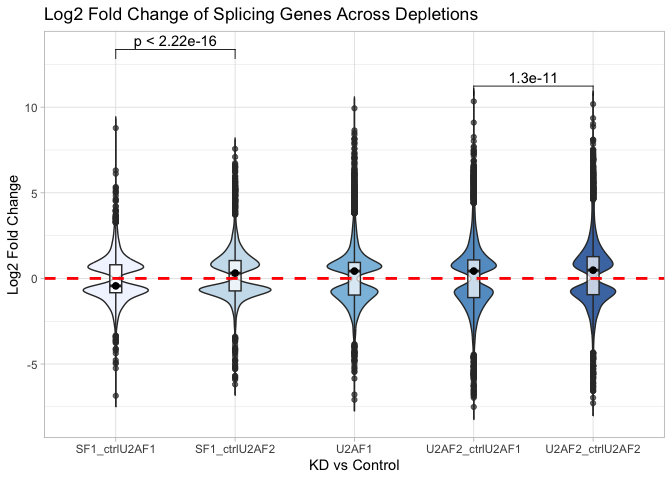

```r
ggplot(reg_violin, aes(x= data_condition, y= log2FoldChange, fill = data_condition)) +
  geom_violin(trim = FALSE, width = 0.6, alpha = 0.8) +
  geom_boxplot(width = 0.1, alpha = 0.7, fill = "white") +
  stat_summary(fun = "median", geom = "point", shape = 19, size = 2) +
  geom_hline(yintercept = 0, linetype = "dashed", color = "red", size = 1) +
  stat_compare_means(comparisons = pair_comparisons,
                     method = "wilcox.test",
                     label = "p.format") +  # show exact p-values
  labs(
    title = "Log2 Fold Change of Splicing Genes Across Depletions",
    x = "KD vs Control",
    y = "Log2 Fold Change"
  ) +
  theme_light() +
  theme(legend.position = "none") +
  scale_fill_brewer(palette = "Blues")
```

However, the distribution of those comparisons looks similarly. The question is that If the choice of control sample between control U2AF2 and control U2AF1 would affect the statistics of expression changes across genes?

## 8.1 Non-parametric test

[figure not shown]

```r
### SF1
bs1 = ggbetweenstats(
  data = reg_violin %>% filter(data_condition %in% c("SF1_ctrlU2AF2", "SF1_ctrlU2AF1")),
  x = data_condition,
  y = log2FoldChange,
  xlab = "",
  type = "nonparametric",           # Use Wilcoxon test
  pairwise.comparisons = TRUE,
  pairwise.display = "significant", # show all pairwise comparisons
  p.adjust.method = "BH",
  results.subtitle = TRUE,
  plot.type = "box",
  centrality.point.args = list(size = 4, shape = 21, fill = "yellow", stroke = 1, alpha =1),
  violinplot.args = list(width = 0.44, alpha = 0.1),
  point.args = list(alpha = 0), # remove points
  boxplot.args = list(width = 0.2, alpha = 0.8, fill = c("cornflowerblue","#8867A1")),
  ggtheme = ggplot2::theme_light()) +
  ggplot2::geom_hline(yintercept = 0, color = "darkred", linetype = "dashed") +
  #ggplot2::scale_color_manual(values = c("#4D6291","#8867A1")) +
  theme(
    plot.title = element_text(color = "black", face = "bold", size = 13))

### U2AF2
bs2 = ggstatsplot::ggbetweenstats(
  data = reg_violin %>%
    dplyr::filter(data_condition %in% c("U2AF2_ctrlU2AF2", "U2AF2_ctrlU2AF1")),
  x = data_condition,
  y = log2FoldChange,
  xlab = "",
  type = "nonparametric",           # Use Wilcoxon test
  pairwise.comparisons = TRUE,
  pairwise.display = "all", # show all pairwise comparisons
  p.adjust.method = "BH",
  results.subtitle = TRUE,
  plot.type = "box",
  centrality.point.args = list(size = 3, shape = 21, fill = "yellow1", stroke = 1, alpha =1),
  violinplot.args = list(width = 0.44, alpha = 0.1),
  point.args = list(alpha = 0), # remove points
  boxplot.args = list(width = 0.2, alpha = 0.8, fill = c("#E56946", "#C43142")),
  ggtheme = ggplot2::theme_light()) +
  ggplot2::theme(
    plot.title = element_text(color = "black", face = "bold", size = 13)) +
  ggplot2::geom_hline(yintercept = 0, color = "darkred", linetype = "dashed")


## combining the individual plots into a single plot
combine_plots(
  list(bs1, bs2),
  plotgrid.args = list(ncol =2L),
  annotation.args = list(
    title = "Non-parametric test between KD vs. 2 different controls",
    subtitle = "Wilcoxon test and rank biserial values"
  )
)
```

::: Rank-biserial is a specific measure of effect size for nonparametric, two-group comparisons (like Wilcoxon rank-sum or Mann-Whitney). It assesses the degree to which scores from one group are systematically greater or lesser than the other.

## 8.2 Intersecting genes between same KDs vs. different controls U2AF2/ U2AF1

**U2AF2**

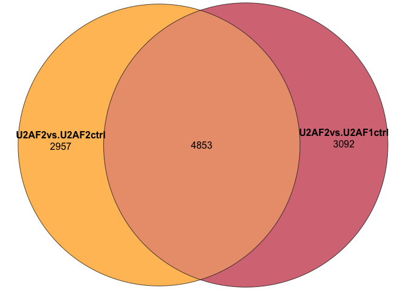

```r
# Create a list
U2AF2_compare_controls = list(U2AF2vs.U2AF2ctrl = regulate_df1$U2AF2_ctrlU2AF2$GeneID,
                              U2AF2vs.U2AF1ctrl = regulate_df1$U2AF2_ctrlU2AF1$GeneID)

U2AF2_compare_controls_eulerr = eulerr::euler(U2AF2_compare_controls)

# Euler plot
plot(U2AF2_compare_controls_eulerr,
      quantities = TRUE,
      fill = c("orange", "#C43142"), # assign colors to each set
     alpha = 0.7,
      stroke_size = 1, # control border size
      set_name_size = 1, # set name size
      text_size = 2)
```

Small r (< 0.1) means the overall distributions of fold-changes are quite similar, which makes sense statistically. But you still find many differentially expressed genes under each comparison. Importantly, most of these genes overlap, indicating the two controls largely affect the same set of genes, although there are some unique ones in each comparison.

**SF1**

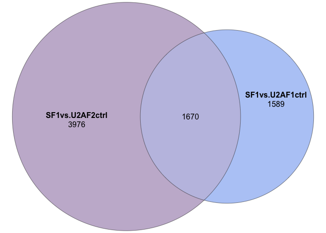

```r
# Create a list
SF1_compare_controls = list(SF1vs.U2AF2ctrl = regulate_df1$SF1_ctrlU2AF2$GeneID,
                            SF1vs.U2AF1ctrl = regulate_df1$SF1_ctrlU2AF1$GeneID)

SF1_compare_controls_eulerr = eulerr::euler(SF1_compare_controls)

# Euler plot
plot(SF1_compare_controls_eulerr,
      quantities = TRUE,
      fill = c("#8867A1", "cornflowerblue"), # assign colors to each set
      alpha = 0.5,
      stroke_size = 1, # control border size
      set_name_size = 1, # set name size
      text_size = 2)
```

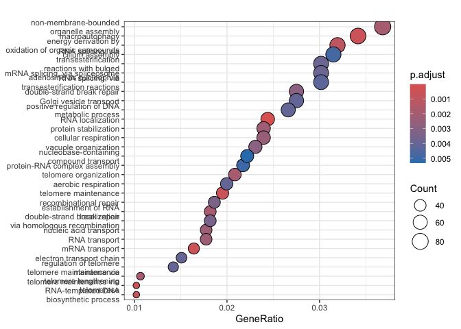

```r
U2AF2_AF2controls_unique = setdiff(regulate_df1$U2AF2_ctrlU2AF2$GeneID,
                                   regulate_df1$U2AF2_ctrlU2AF1$GeneID)

ego_U2AF2_AF2controls_unique = enrichGO(gene = U2AF2_AF2controls_unique,
                                        OrgDb = org.Hs.eg.db,
                                        keyType = "ENSEMBL",
                                        ont = "BP",           # or "MF", "CC"
                                        pAdjustMethod = "BH",
                                        pvalueCutoff = 0.05,
                                        readable = TRUE)

dotplot(ego_U2AF2_AF2controls_unique, showCategory = 30) +
  theme_bw()
```

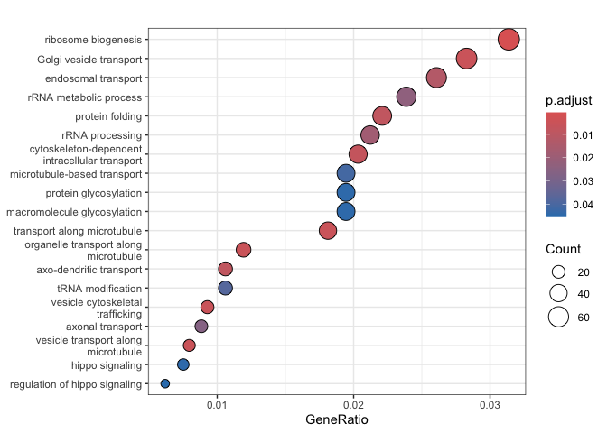

```r
U2AF2_AF1controls_unique = setdiff(regulate_df1$U2AF2_ctrlU2AF1$GeneID,
                                   regulate_df1$U2AF2_ctrlU2AF2$GeneID)

ego_U2AF2_AF1controls_unique = enrichGO(gene = U2AF2_AF1controls_unique,
                                        OrgDb = org.Hs.eg.db,
                                        keyType = "ENSEMBL",
                                        ont = "BP",           # or "MF", "CC"
                                        pAdjustMethod = "BH",
                                        pvalueCutoff = 0.05,
                                        readable = TRUE)

dotplot(ego_U2AF2_AF1controls_unique, showCategory = 30) +
  theme_bw()
```